# Factors Influencing Deaths In Heart Failure Patients

Project Groups11  
Parth Deshmukh(S3825055), Subbiah Soundarapandian(S3825012), Sudershan Ravi(S3829895)

• **INTRODUCTION**

Heart failure is the number one cause for death worldwide, which accounts for over 17 million lives i.e almost 31% of all people die due to heart failures. Most of the cardiovascular diseases can be prevented by addressing behavioural risk factors such as use of tobacco, unhealthy diet, hypertension , diabetes and many other physical inactivites.

In the first phase of this project we will analyze in total 12 features that can be used to predict the cause for the heart failure leading to death. So, we will analyze a dataset of 299 patients with heart failure which was collected in 2015. We will apply categorical data analysis to predict the patients who died and rank the features corresponding to the most important risk factors which lead to death.In this analysis we will be focussing majorly on age, platelets count, serium creatinine level in the blood and ejection fraction features to summarise our findings and find a comprehensive outcome based on this features leading to death due to heart failures.

In the next phase of this project we will be using multinominal regression technique to further extract the key features to make a conclusive statement on the visualized data from phase-1.

• **DATA SET SOURCE AND DESCRIPTION**

The dataset is referred from (“Heart Failure Prediction”, 2020) with compilation of various datasets from other sources. The dataset has 13 features and 299 observations which describes the reasons for health failures.The description for the dataset is provided below :

Age : Age of Patient.  
Anaemia : Decrease of red blood cells or hemoglobin (0:Patient don’t have Anaemia , 1: Patient have Anaemia ).  
High Blood pressure : Does a patient has hypertension (0:Patient don’t have High Blood Pressure , 1: Patient have High Blood Pressure ).  
Creatinine phosphokinase : Level of CPK enzyme in the blood.  
Diabetes : Does the patient has diabetes (0:Patient don’t have Diabetes, 1: Patient have Diabetes).  
Ejection fraction : percentage of blood leaving the heart at each contraction.  
Sex : Male or Female (0:female ,1:Male ).  
Platelets : Platelets in the blood.  
Serum Ceratinine : Level of Ceratinine in the blood.  
Serium sodium : Level of sodium in the blood.  
Smoking : Does the patient smokes (0: Patient don’t smoke, 1: Patient smoke ).  
Time : Follow-up period.  
Death Event : Did the patient died during the follow-up period (0: NO, 1: YES ).

• **DATA PREPARATION**

Loading the packages required and reading the dataset.

```r
library(readr)
assign_ds <- read.csv("Project Groups11_data.csv")
```

Handling the missing values and removing the irrelevant column (Time) as it is not necessary for our analysis.

```r
assign_ds <- na.omit(assign_ds)
assign_ds <- assign_ds[,-12]
```

Statistical Quantitative description of the category features :-

```r
#ANAEMIA
assign_ds_an <- as.data.frame(table(factor(assign_ds[, 2],labels = c("Non-Anaemic","Anaemic"),levels=c(0,1))))
assign_ds_an
```

```
##          Var1 Freq
## 1 Non-Anaemic  170
## 2     Anaemic  129
```

```r
#DIABETES
assign_ds_dia <- as.data.frame(table(factor(assign_ds[, 4],labels = c("Non-Diabetic","Diabetic"),levels=c(0,1))))
assign_ds_dia
```

```
##           Var1 Freq
## 1 Non-Diabetic  174
## 2     Diabetic  125
```

```r
#SEX
assign_ds_sex <- as.data.frame(table(factor(assign_ds[, 10],labels = c("Female","Male"),levels=c(0,1))))
assign_ds_sex
```

```
##     Var1 Freq
## 1 Female  105
## 2   Male  194
```

```r
#SMOKING
assign_ds_smok <- as.data.frame(table(factor(assign_ds[, 11],labels = c("Non-Smoker","Smoker"),levels=c(0,1))))
assign_ds_smok
```

```
##         Var1 Freq
## 1 Non-Smoker  203
## 2     Smoker   96
```

```r
#DEATH_EVENT
assign_ds_death <- as.data.frame(table(factor(assign_ds[, 12],labels = c("Patient Survived","Patient Died"),levels=c(0,1))))
assign_ds_death
```

```
##               Var1 Freq
## 1 Patient Survived  203
## 2     Patient Died   96
```

Subsetting the dataset into people who died and people survived.

```r
library(dplyr)
dead_ppl <- filter(assign_ds, DEATH_EVENT == 1)
alive_ppl <- filter(assign_ds, DEATH_EVENT == 0)
```

Histogram of multiple factors

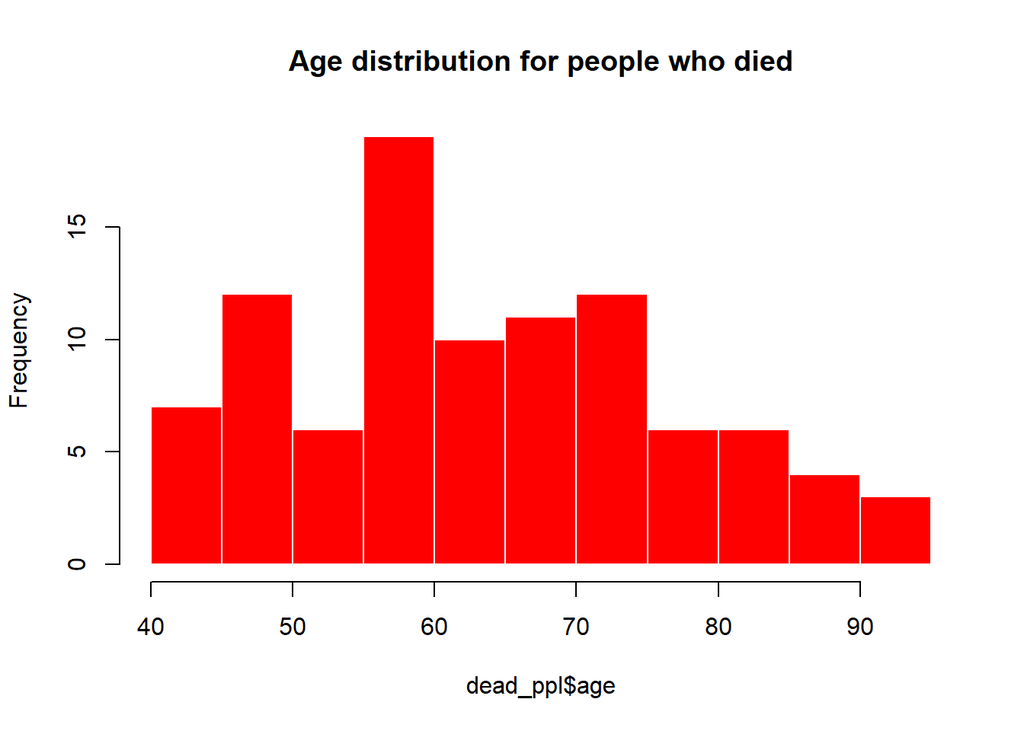

```r
#AGE GROUP
hist(dead_ppl$age,border = "white", col = "red", main = "Age distribution for people who died")
```

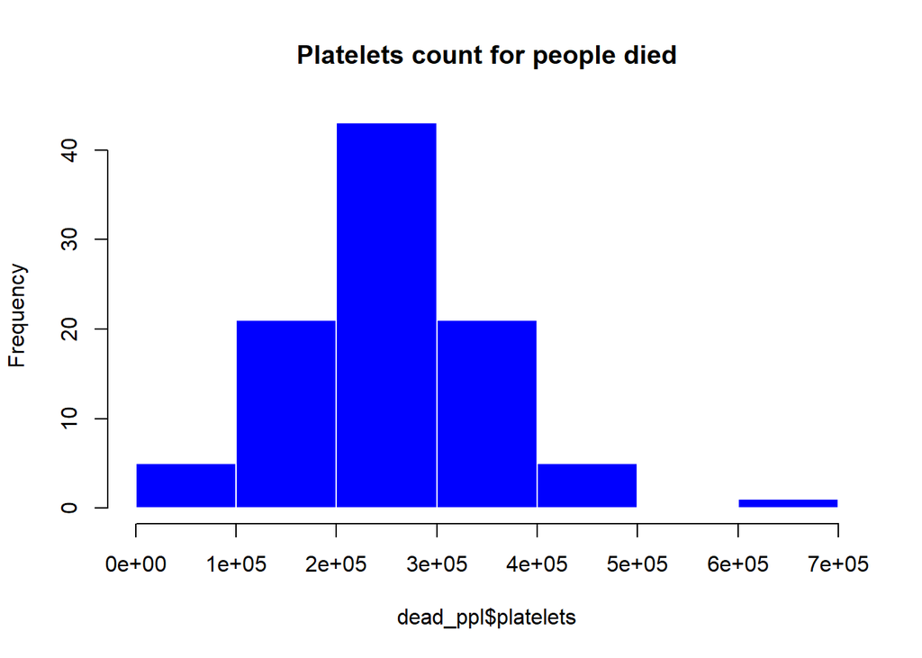

```r
#PLATELETS
hist(dead_ppl$platelets,border = "white", col = "blue",main = "Platelets count for people died")
```

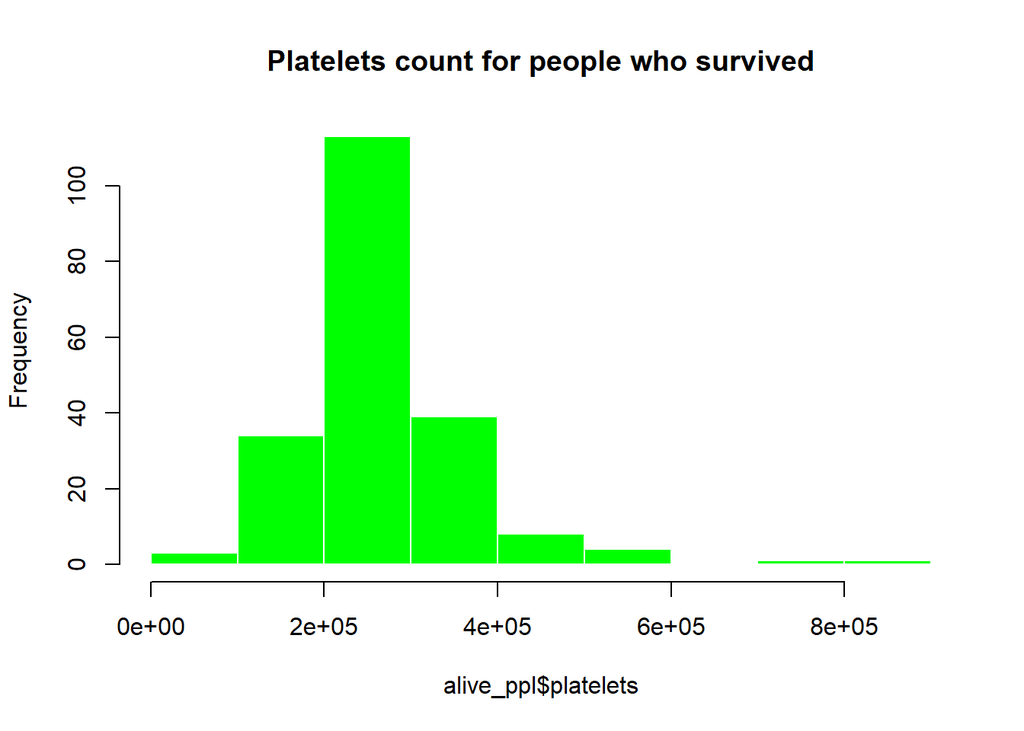

```r
hist(alive_ppl$platelets,border = "white", col = "green",main = "Platelets count for people who survived")
```

```r
summary(dead_ppl$platelets)
```

```
##    Min. 1st Qu.  Median    Mean 3rd Qu.    Max.
##   47000  197500  258500  256381  311000  621000
```

```r
summary(alive_ppl$platelets)
```

```
##    Min. 1st Qu.  Median    Mean 3rd Qu.    Max.
##   25100  219500  263000  266658  302000  850000
```

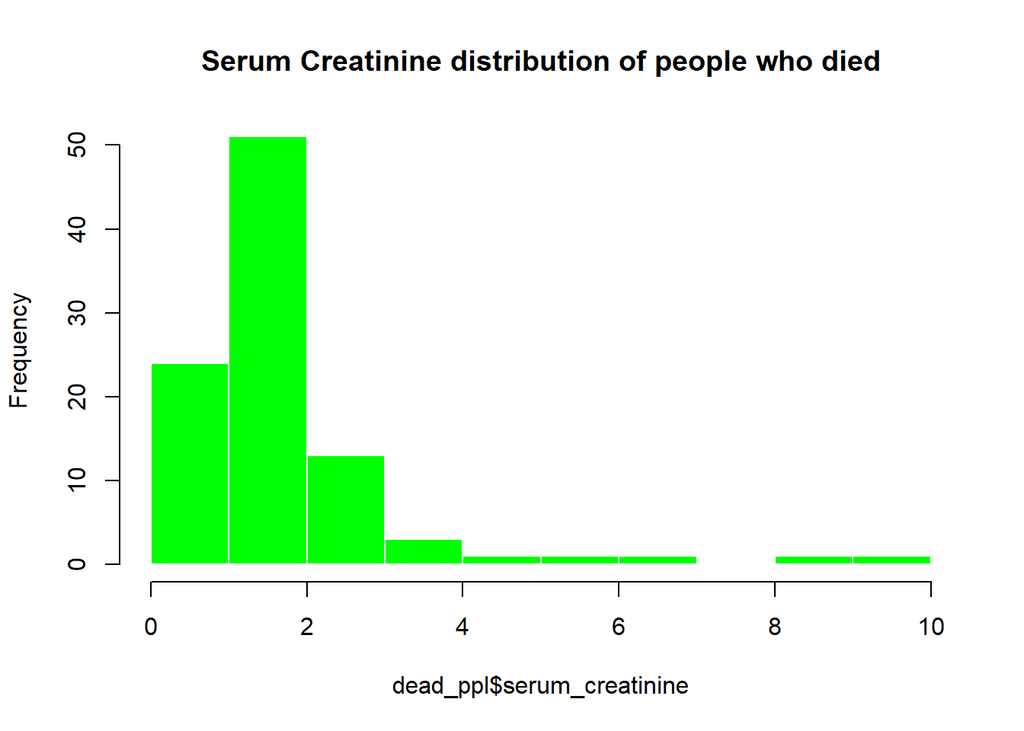

```r
#SERUM CERATININE
hist(dead_ppl$serum_creatinine,border = "white", col = "green", main = "Serum Creatinine distribution of people who died")
```

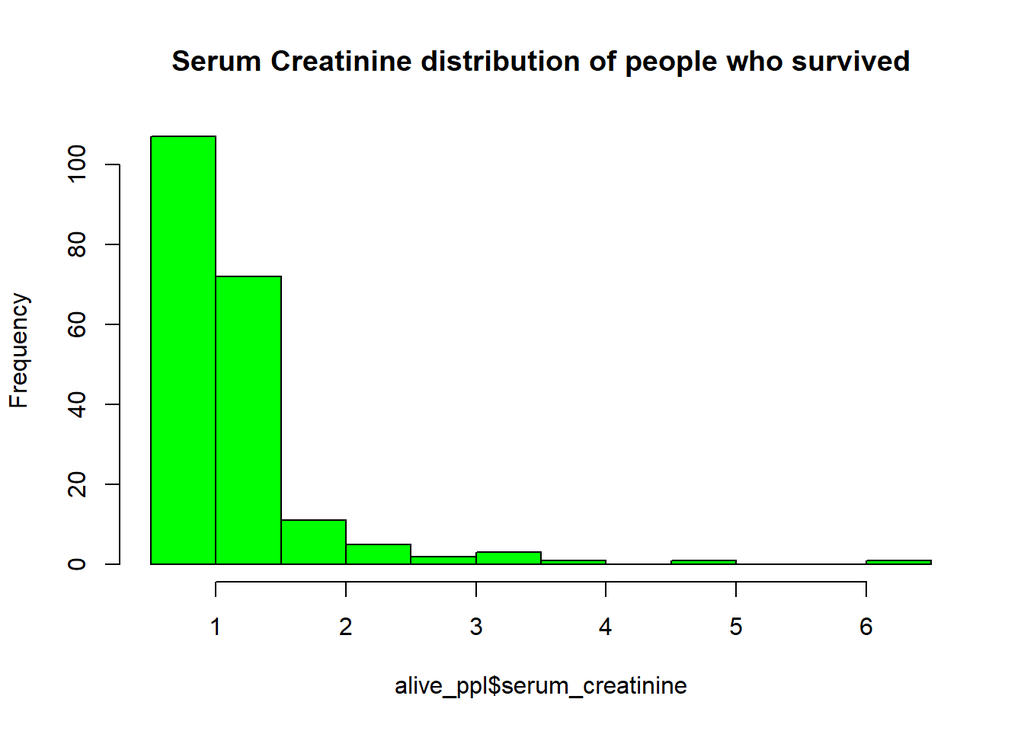

```r
hist(alive_ppl$serum_creatinine,border = "black", col = "green", main = "Serum Creatinine distribution of people who survived")
```

```r
summary(dead_ppl$serum_creatinine)
```

```
##    Min. 1st Qu.  Median    Mean 3rd Qu.    Max.
##   0.600   1.075   1.300   1.836   1.900   9.400
```

```r
summary(alive_ppl$serum_creatinine)
```

```
##    Min. 1st Qu.  Median    Mean 3rd Qu.    Max.
##   0.500   0.900   1.000   1.185   1.200   6.100
```

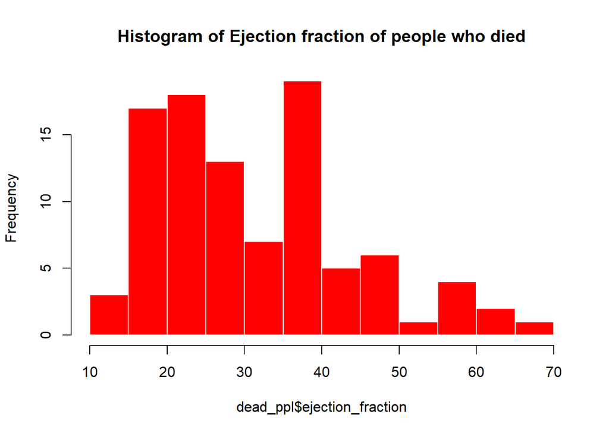

```r
#EJECTION FRACTION
hist(dead_ppl$ejection_fraction,border = "white", col = "red", main = "Histogram of Ejection fraction of people who died")
```

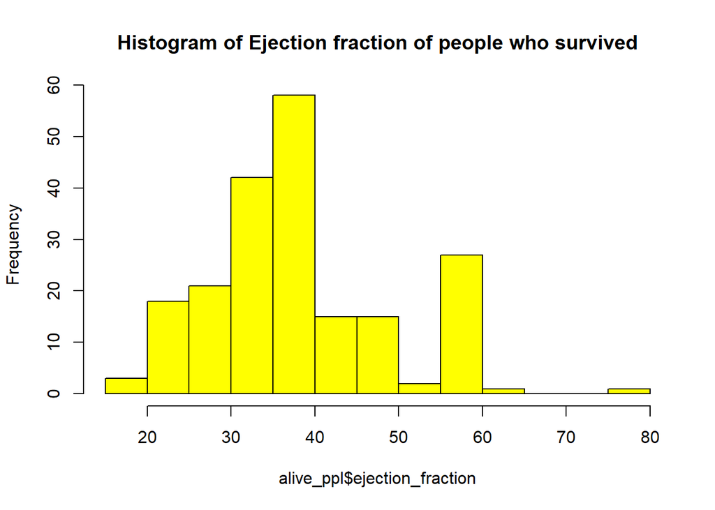

```r
hist(alive_ppl$ejection_fraction,border = "black", col = "yellow", main = "Histogram of Ejection fraction of people who survived")
```

```r
summary(dead_ppl$ejection_fraction)
```

```
##    Min. 1st Qu.  Median    Mean 3rd Qu.    Max.
##   14.00   25.00   30.00   33.47   38.00   70.00
```

```r
summary(alive_ppl$ejection_fraction)
```

```
##    Min. 1st Qu.  Median    Mean 3rd Qu.    Max.
##   17.00   35.00   38.00   40.27   45.00   80.00
```

Pie charts for different factors.

```r
#ANAEMIA
anaemic <- table(assign_ds$DEATH_EVENT,assign_ds$anaemia,dnn = c("Death Event","Anaemic"))
rownames(anaemic) = c("alive","dead")
colnames(anaemic) = c("anaemic","not_anaemic")
anaemic
```

```
##            Anaemic
## Death Event anaemic not_anaemic
##       alive     120          83
##       dead       50          46
```

```r
anaemic_pct <- anaemic[2,]
anaemic_pct <- round(anaemic_pct/sum(anaemic_pct)*100,2)
anaemic_pct
```

```
##     anaemic not_anaemic
##       52.08       47.92
```

```r
labels_an = paste(anaemic_pct, "%", sep = "")
labels_an
```

```
## [1] "52.08%" "47.92%"
```

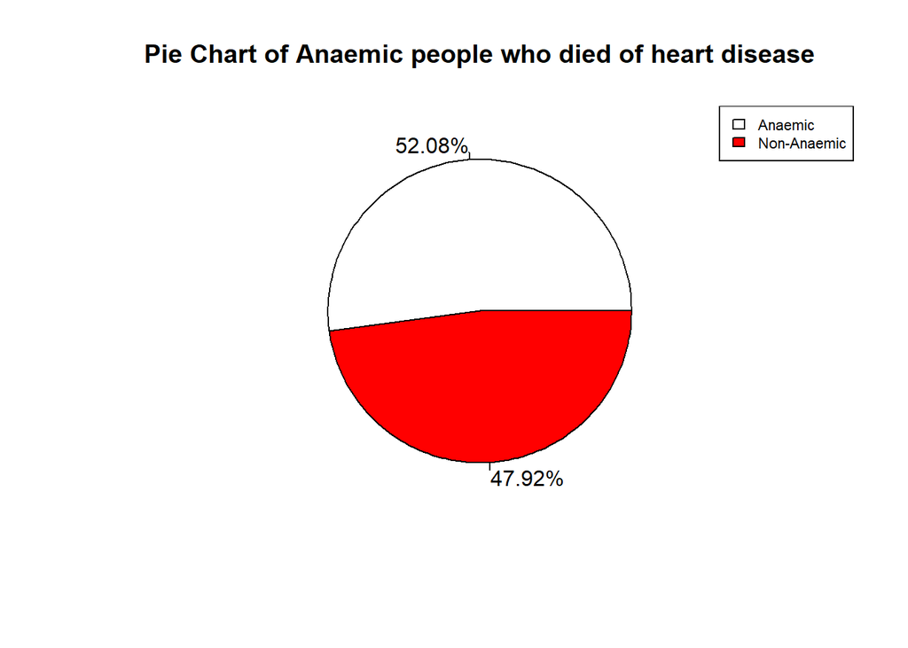

```r
pie(anaemic[2,],labels = labels_an,main = "Pie Chart of Anaemic people who died of heart disease"
,col = c("white","red"))
legend("topright",c("Anaemic","Non-Anaemic"),fill = c("white","red"), cex = 0.7)
```

```r
#SMOKING
smoking <- table(assign_ds$DEATH_EVENT,assign_ds$smoking,dnn = c("Death Event","Smoking"))
rownames(smoking) = c("alive","dead")
colnames(smoking) = c("Smoker","Non-Smoker")
smoking
```

```
##            Smoking
## Death Event Smoker Non-Smoker
##       alive    137         66
##       dead      66         30
```

```r
smoking_pct <- smoking[2,]
smoking_pct <- round(smoking_pct/sum(smoking_pct)*100,2)
smoking_pct
```

```
##     Smoker Non-Smoker
##      68.75      31.25
```

```r
labels_sm = paste(smoking_pct, "%", sep = "")
labels_sm
```

```
## [1] "68.75%" "31.25%"
```

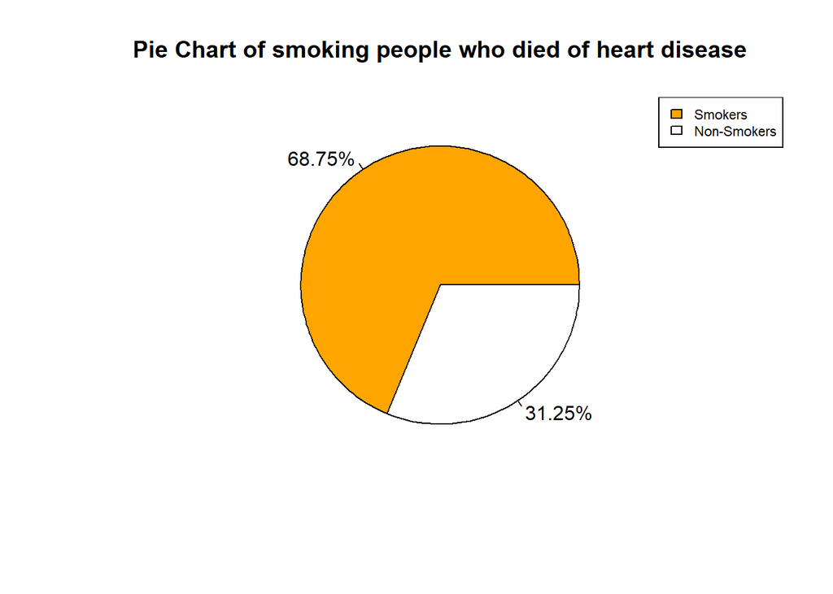

```r
pie(smoking[2,],labels = labels_sm,main = "Pie Chart of smoking people who died of heart disease"
    ,col = c("Orange","White"))
legend("topright",c("Smokers","Non-Smokers"),fill = c("Orange","white"),cex = 0.7)
```

```r
#DIABETES
diabetes <- table(assign_ds$DEATH_EVENT,assign_ds$diabetes,dnn = c("Death Event","diabetes"))
rownames(diabetes) = c("alive","dead")
colnames(diabetes) = c("Diabetic","Non-Diabetic")
diabetes
```

```
##            diabetes
## Death Event Diabetic Non-Diabetic
##       alive      118           85
##       dead        56           40
```

```r
diabetes_pct <- diabetes[2,]
diabetes_pct <- round(diabetes_pct/sum(diabetes_pct)*100,2)
diabetes_pct
```

```
##     Diabetic Non-Diabetic
##        58.33        41.67
```

```r
labels_db = paste(diabetes_pct, "%", sep = "")
labels_db
```

```
## [1] "58.33%" "41.67%"
```

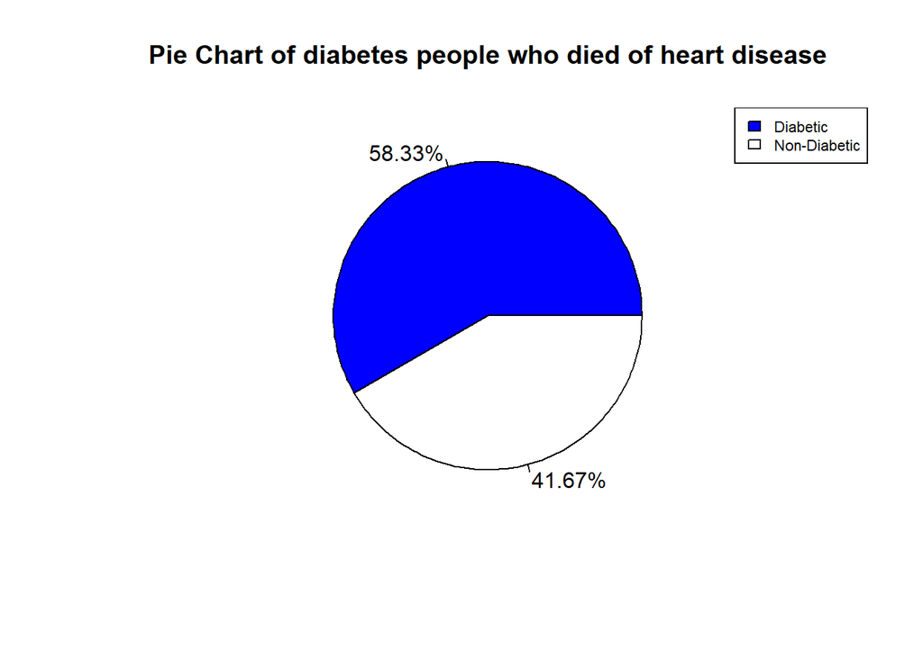

```r
pie(diabetes[2,],labels = labels_db,main = "Pie Chart of diabetes people who died of heart disease"
    ,col = c("Blue","White"))
legend("topright",c("Diabetic","Non-Diabetic"),fill = c("Blue","white"), cex = 0.7)
```

```r
#BLOOD PRESSURE
high_blood_pressure <- table(assign_ds$DEATH_EVENT,assign_ds$high_blood_pressure,dnn = c("Death Event","high_blood_pressure"))
rownames(high_blood_pressure) = c("alive","dead")
colnames(high_blood_pressure) = c("High_BP","Not High_BP")
high_blood_pressure
```

```
##            high_blood_pressure
## Death Event High_BP Not High_BP
##       alive     137          66
##       dead       57          39
```

```r
prop.table(high_blood_pressure)
```

```
##            high_blood_pressure
## Death Event   High_BP Not High_BP
##       alive 0.4581940   0.2207358
##       dead  0.1906355   0.1304348
```

```r
high_blood_pressure_pct <- high_blood_pressure[2,]
high_blood_pressure_pct <- round(high_blood_pressure_pct/sum(high_blood_pressure_pct)*100,2)
high_blood_pressure_pct
```

```
##     High_BP Not High_BP
##       59.38       40.62
```

```r
labels_bp = paste(high_blood_pressure_pct, "%", sep = "")
labels_bp
```

```
## [1] "59.38%" "40.62%"
```

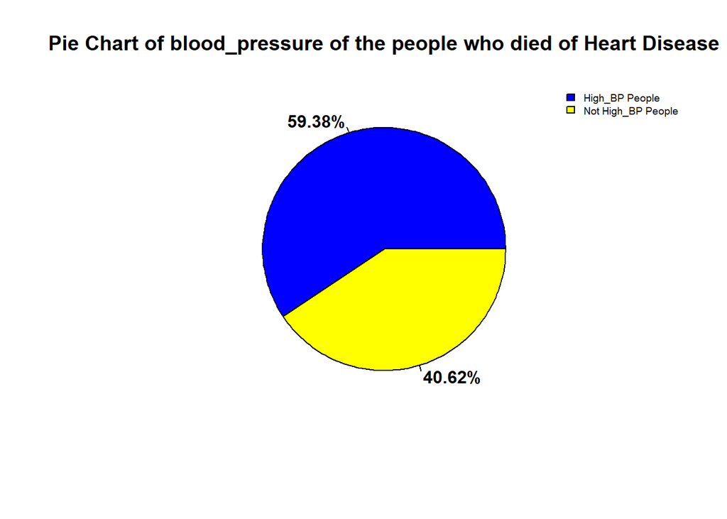

```r
pie(high_blood_pressure[2,], labels = labels_bp ,font = 2,main = "Pie Chart of blood_pressure of the people who died of Heart Disease"
    ,col = c("blue","yellow"))
legend("topright",c("High_BP People","Not High_BP People"),fill = c("blue","yellow"), bty = "n",cex = 0.6)
```

Bar charts for various factors based on sex.

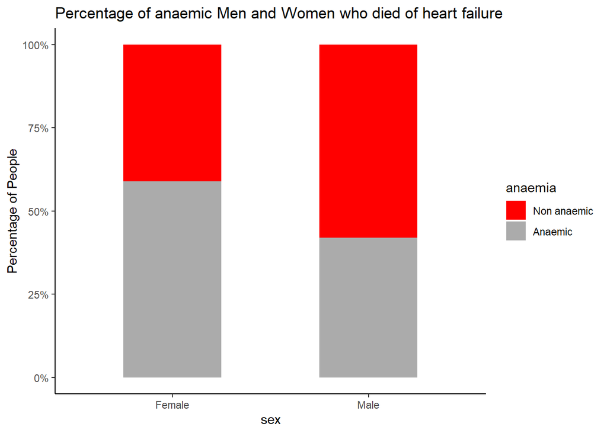

```r
library(ggplot2)
dead_ppl$anaemia <- factor(dead_ppl$anaemia, labels = c("Non anaemic", "Anaemic"))
dead_ppl$sex <- factor(dead_ppl$sex, labels = c("Female","Male"))
dead_ppl$high_blood_pressure <- factor(dead_ppl$high_blood_pressure, labels = c("Not High BP","High BP"))
dead_ppl$smoking <- factor(dead_ppl$smoking,labels = c("Non-Smokers","Smokers"))
dead_ppl$diabetes <- factor(dead_ppl$diabetes,labels = c("Non-Diabetic","Diabetic"))

anaemia_gender<-ggplot(data=dead_ppl, aes(x = sex, fill=anaemia)) +
  geom_bar(stat = "count",position = "fill",width = 0.5) + theme_classic() + labs(y = "Percentage of People") + ggtitle("Percentage of anaemic Men and Women who died of heart failure ")
anaemia_gender <- anaemia_gender+ scale_fill_manual(values = c("#FF0000","#ABABAB")) + scale_y_continuous(labels = scales::percent)
anaemia_gender
```

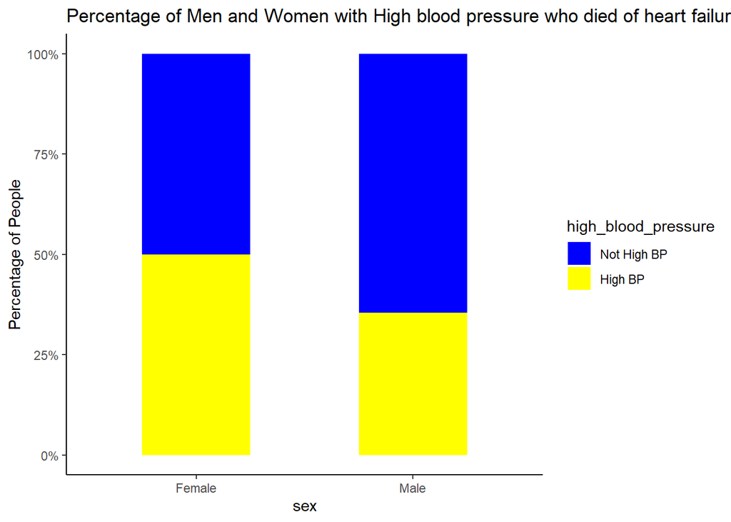

```r
highbp_gender <- ggplot(data=dead_ppl, aes(x = sex, fill = high_blood_pressure)) +
    geom_bar(stat = "count",position = "fill",width = 0.5) + theme_classic() +  labs(y = "Percentage of People") + ggtitle("Percentage of Men and Women with High blood pressure who died of heart failure ")
highbp_gender <- highbp_gender+ scale_fill_manual(values = c("#0000FF","#FFFF00")) + scale_y_continuous(labels = scales::percent)
highbp_gender
```